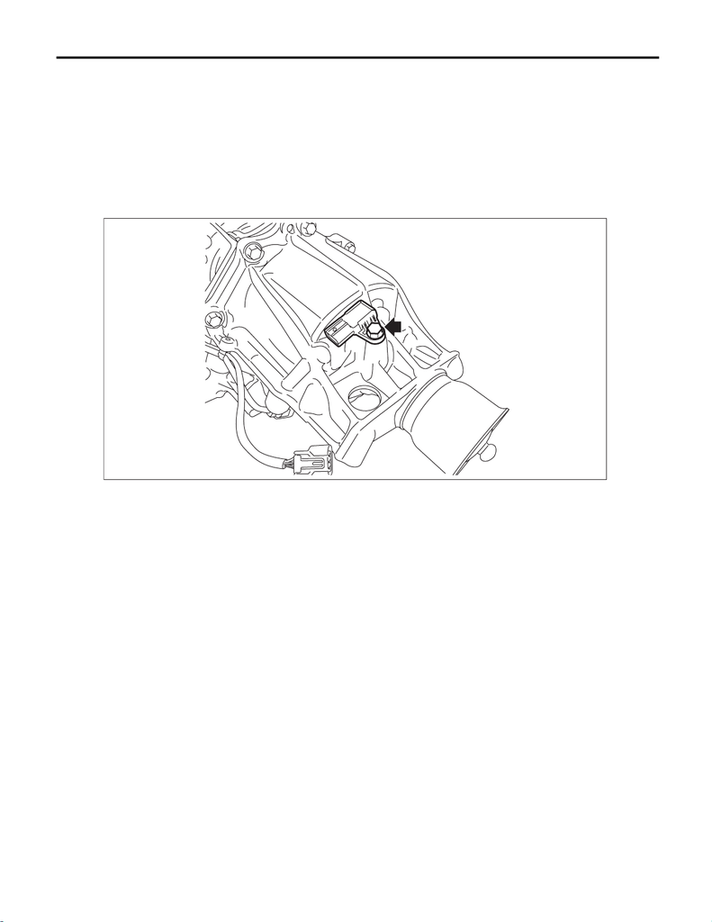

CVT(TR690)-107

Rear Wheel Speed Sensor

CONTINUOUSLY VARIABLE TRANSMISSION

18.Rear Wheel Speed Sensor

A: REMOVAL

1) Disconnect the ground terminal from battery sensor. <Ref. to NT-5, BATTERY, NOTE, Note.>

2) Lift up the vehicle.

3) Clean the transmission exterior.

4) Remove the bolts which connect the center exhaust pipe (rear) and rear exhaust pipe.

5) Remove the bolts holding the center exhaust cover, and move the center exhaust cover to the rear.

6) Disconnect the rear wheel speed sensor connector.

7) Remove the rear wheel speed sensor.

AT-07387

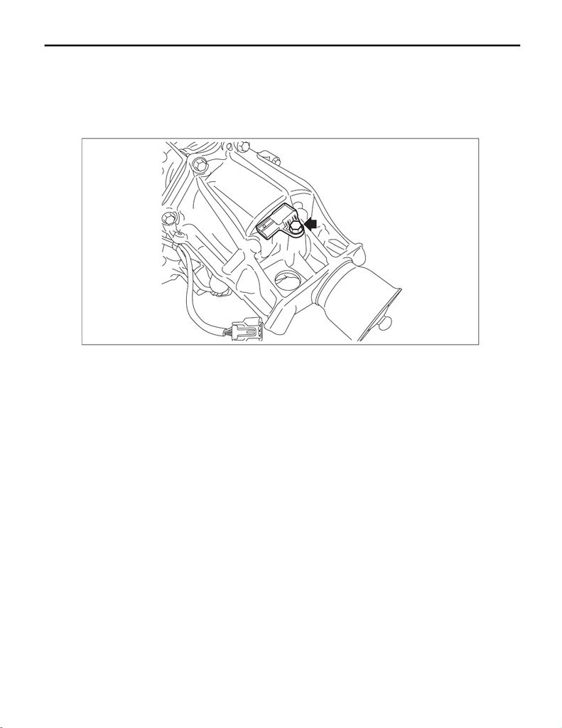

CVT(TR690)-108

Rear Wheel Speed Sensor

CONTINUOUSLY VARIABLE TRANSMISSION

B: INSTALLATION

1) Install the rear wheel speed sensor.

NOTE:

Use new O-rings.

Tightening torque:

5 N·m (0.5 kgf-m, 3.7 ft-lb)

2) Connect the rear wheel speed sensor connector.

3) Install the heat shield cover.

Tightening torque:

18 N·m (1.8 kgf-m, 13.3 ft-lb)

4) Tighten the bolts which connect the center exhaust pipe (rear) and rear exhaust pipe.

NOTE:

Use a new gasket.

Tightening torque:

18 N·m (1.8 kgf-m, 13.3 ft-lb)

5) Lower the vehicle.

6) Connect the ground terminal to battery sensor. <Ref. to NT-5, BATTERY, NOTE, Note.>

AT-07387

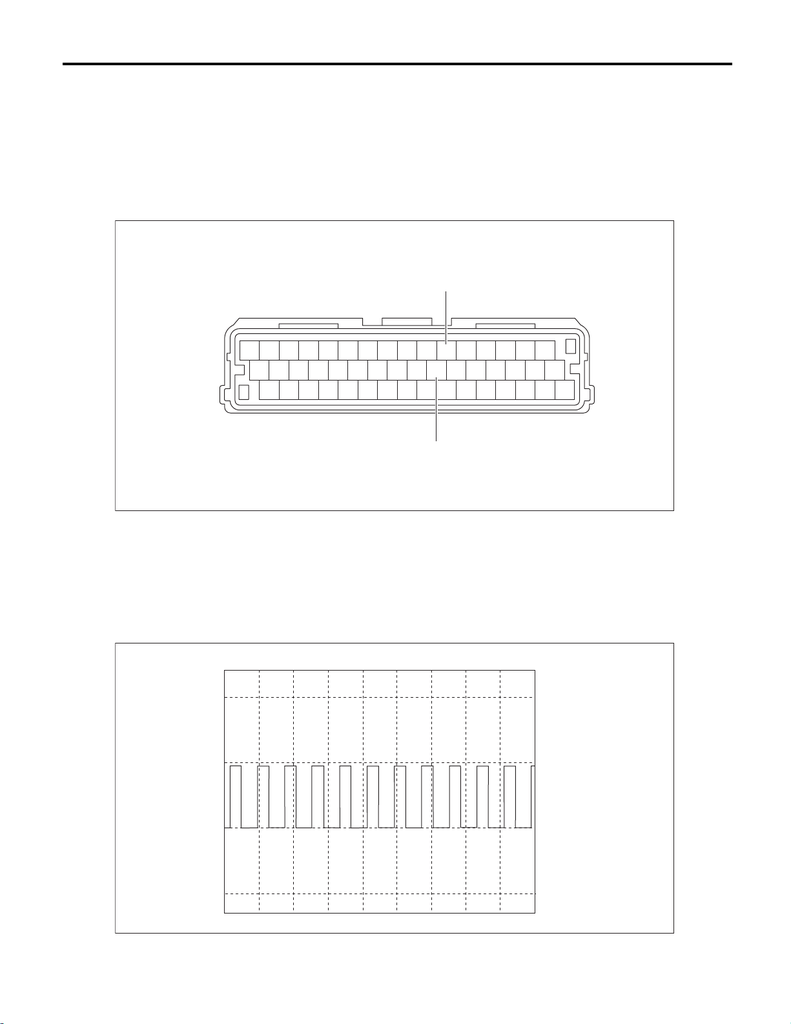

CVT(TR690)-109

Rear Wheel Speed Sensor

CONTINUOUSLY VARIABLE TRANSMISSION

C: INSPECTION

1) Remove the bulkhead harness connector from TCM. <Ref. to CVT(TR690)-126, REMOVAL, Transmis-

sion Control Module (TCM).>

2) Set the ST between the TCM and bulkhead harness.

ST 18460AA040 CHECK BOARD

3) Set the probe of oscilloscope to the check board connector.

Terminals:

No. 11 (+) — No. 26 (–)

4) Lift up the vehicle and raise the vehicle speed up to 20 km/h (12 MPH).

5) Check the waveform of rear wheel speed sensor when vehicle speed is at 20 km/h (12 MPH).

NOTE:

The waveform cycle changes as the speed changes.

(A) + probe

(B) – probe

123456789

10 11 12 13 14 15 16

17 18 19 20 21 22 23 24 25 26 27 28 29 30 31 32

33 34 35 36 37 38 39 40 41 42 43 44 45 46 47 48

(A)

(B)

CVT00513

AT-08036

0

5

-5

10

(V)